# Group Name: Pi

#### Amenities

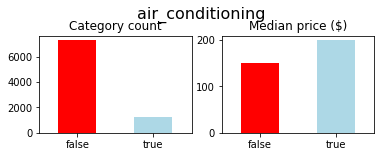

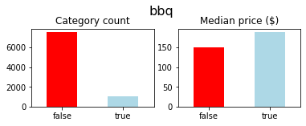

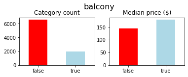

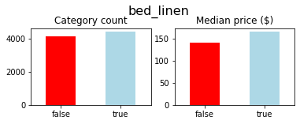

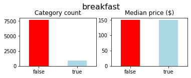

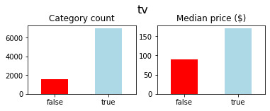

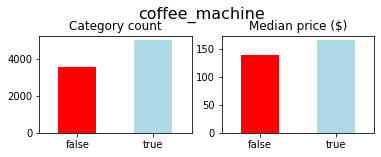

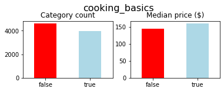

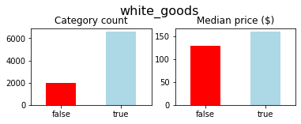

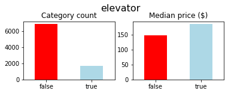

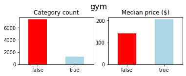

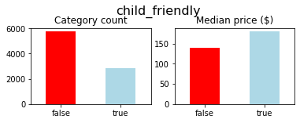

[8 more figures not shown]

```python
for col in df.iloc[:,31:-2].columns:
    binary_count_price_plot(col, figsize=(6,2))
```

# Preparing the data for Modeling

#### Dropping columns and assessing multi-collinearity

```python
#one-hot encoding for categorical variables
transformed_df = pd.get_dummies(df)
```

```python
def collinearity_heatmap(df, figsize=(11,9)):

    """
    Creates a heatmap of correlations between features in the df. A figure size can optionally be set.
    """

    # Set the style of the visualization
    sns.set(style="white")

    # Create a covariance matrix
    corr = df.corr()

    # Generate a mask the size of our covariance matrix
    mask = np.zeros_like(corr, dtype=np.bool)
    mask[np.triu_indices_from(mask)] = True

    # Set up the matplotlib figure
    f, ax = plt.subplots(figsize=figsize)

    # Generate a custom diverging colormap
    cmap = sns.diverging_palette(220, 10, as_cmap=True)

    # Draw the heatmap with the mask and correct aspect ratio
    sns.heatmap(corr, mask=mask, cmap=cmap, center=0, square=True, linewidths=.5, cbar_kws={"shrink": .5}, vmax=corr[corr != 1.0].max().max());
```

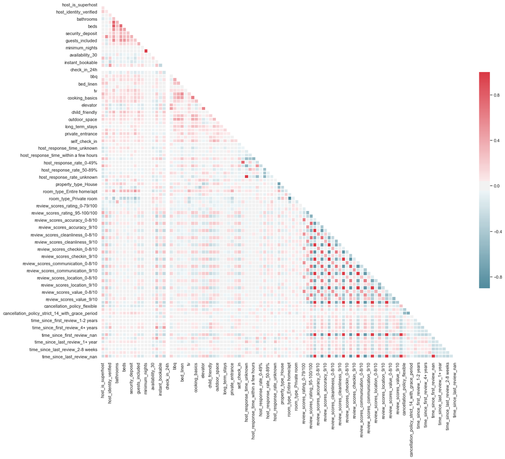

```python
collinearity_heatmap(transformed_df, figsize=(20,20))
```

Areas of multi-collinearity:

- Beds, bedrooms, guests included and the number of people (top of produced heatmap) that a property accommodates are highly correlated. The number of people accommodated is a more high priority search parameter on AirBnB, as it is more relevant for private and shared rooms than the number of bedrooms.
- Tthere are perfect correlations between NaN reviews (listings that are not reviewed yet) for different review categories, and first and last review times. NaN categories can therefore be dropped.
- The same is true of unknown host response rates and times. One of these (rate) will be dropped.
- There is a correlation between a 0-49% response rate, and an average response time of a few days or more. One of these (rate) will be dropped.
- There are strong negative correlations between houses and apartments, and between private rooms and entire homes (as these were the main two categories of their features before they were one-hot encoded). Although these are important categories, one of each will be dropped in order to reduce multi-collinearity (apartments and private rooms, as these are the second most common categories).

```python
# Dropping collinear features
to_drop = ['beds',
           'bedrooms',
           'guests_included',
           'host_response_rate_unknown',
           'host_response_rate_0-49%',
           'property_type_Apartment',
           'room_type_Private room',
           'check_in_24h']
to_drop.extend(list(transformed_df.columns[transformed_df.columns.str.endswith('nan')]))

transformed_df.drop(to_drop, axis=1, inplace=True)
```

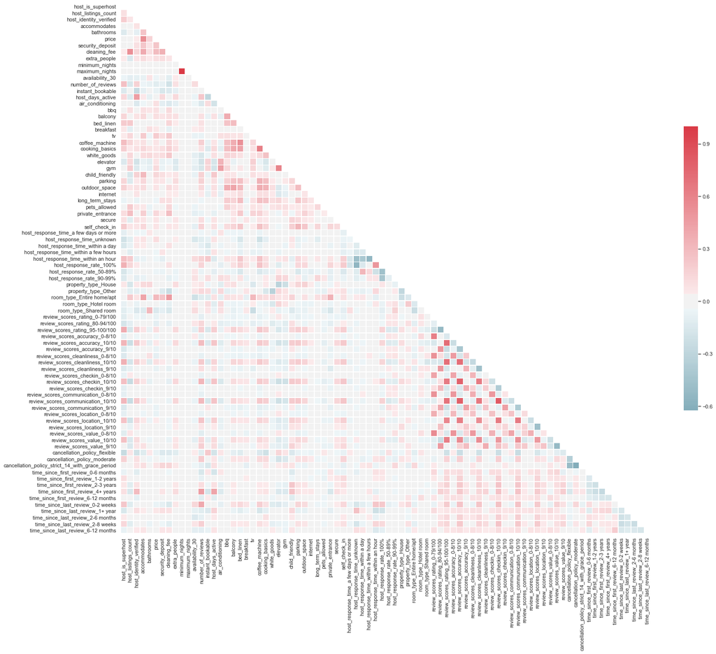

```python
# Final assessment of multi-collinearity
collinearity_heatmap(transformed_df.drop(list(transformed_df.columns[transformed_df.columns.str.startswith('borough')]), axis=1), figsize=(25,22))
```

There are still some fairly strong correlations between highly rated properties of different reviews categories (if a property gets a 10/10 for one category, it is likely to get a 10/10 for other categories). However, these will be left in for now and can be experimented with later to see if removing them improves the model.

#### Standardizing and normalizing

```python
numerical_columns = ['accommodates', 'bathrooms', 'cleaning_fee', 'extra_people', 'host_days_active', 'host_listings_count', 'maximum_nights', 'minimum_nights', 'number_of_reviews', 'price', 'security_deposit']
```

```
array([[<matplotlib.axes._subplots.AxesSubplot object at 0x000001C1E3CD22B0>,
      dtype=object)
```

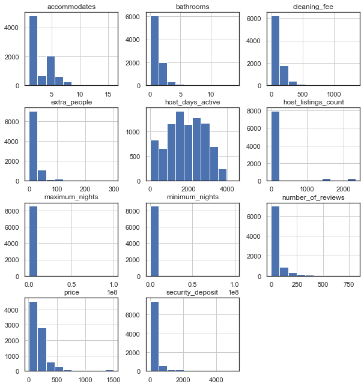

```python
transformed_df[numerical_columns].hist(figsize=(10,11))
```

```python
# Log transforming columns
numerical_columns = [i for i in numerical_columns if i not in ['availability_90', 'host_days_active']] # Removing items not to be transformed

for col in numerical_columns:
    transformed_df[col] = transformed_df[col].astype('float64').replace(0.0, 0.01) # Replacing 0s with 0.01
    transformed_df[col] = np.log(transformed_df[col])
```

```
array([[<matplotlib.axes._subplots.AxesSubplot object at 0x000001C1E3AF72B0>,
      dtype=object)
```

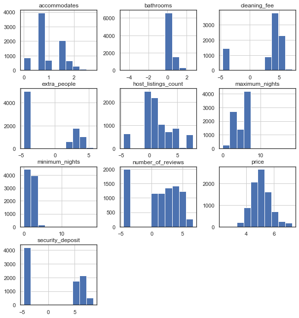

```python
transformed_df[numerical_columns].hist(figsize=(10,11))
```

#### Separating and scaling X and Y

```python
# Separating X and y
X = transformed_df.drop('price', axis=1)
y = transformed_df.price

# Scaling
scaler = StandardScaler()
X = pd.DataFrame(scaler.fit_transform(X), columns=list(X.columns))
```

# Building the Neural Networks

In this section we'll be using neural network models to predict an Airbnb listing's price.

The evaluation metrics used will be mean squared error (for loss) and r squared (for accuracy).

```python
# Splitting into train and test sets
X_train, X_test, y_train, y_test = train_test_split(X, y, test_size=0.2, random_state=123)
```

### Model 1: Xgboost

Before building a neural network, a vanilla XGBoost model will be used to predict price, in order to provide a baseline level of accuracy and a measure of feature importance. This most give the best achievable accuracy (other than possible small accuracy increases from hyper-parameter tuning) due to XGBoost's performance.

```python
xgb_reg_start = time.time()

xgb_reg = xgb.XGBRegressor()
xgb_reg.fit(X_train, y_train)
training_preds_xgb_reg = xgb_reg.predict(X_train)
val_preds_xgb_reg = xgb_reg.predict(X_test)

xgb_reg_end = time.time()

print(f"Time taken to run: {round((xgb_reg_end - xgb_reg_start)/60,1)} minutes")
print("\nTraining MSE:", round(mean_squared_error(y_train, training_preds_xgb_reg),4))
print("Validation MSE:", round(mean_squared_error(y_test, val_preds_xgb_reg),4))
print("\nTraining r2:", round(r2_score(y_train, training_preds_xgb_reg),4))
print("Validation r2:", round(r2_score(y_test, val_preds_xgb_reg),4))
```

```
Time taken to run: 0.0 minutes

Training MSE: 0.0298
Validation MSE: 0.1481

Training r2: 0.9415
Validation r2: 0.7098
```

```python
ft_weights_xgb_reg = pd.DataFrame(xgb_reg.feature_importances_, columns=['weight'], index=X_train.columns)
ft_weights_xgb_reg.sort_values('weight', inplace=True)
ft_weights_xgb_reg
```

|  | weight |
| --- | --- |
| review_scores_checkin_10/10 | 0.000147 |
| review_scores_accuracy_0-8/10 | 0.001177 |
| review_scores_rating_0-79/100 | 0.001659 |
| time_since_last_review_2-8 weeks | 0.002308 |
| review_scores_checkin_0-8/10 | 0.002351 |
| self_check_in | 0.002467 |
| review_scores_value_9/10 | 0.002796 |
| pets_allowed | 0.002847 |
| review_scores_value_0-8/10 | 0.002882 |
| host_identity_verified | 0.002918 |
| review_scores_checkin_9/10 | 0.002997 |
| host_is_superhost | 0.003080 |
| review_scores_communication_0-8/10 | 0.003286 |
| time_since_first_review_6-12 months | 0.003328 |
| time_since_last_review_6-12 months | 0.003330 |
| host_response_time_within a day | 0.003511 |
| review_scores_cleanliness_0-8/10 | 0.003598 |
| child_friendly | 0.003631 |
| cancellation_policy_strict_14_with_grace_period | 0.003640 |
| outdoor_space | 0.003673 |
| review_scores_communication_10/10 | 0.003680 |
| review_scores_cleanliness_9/10 | 0.003684 |
| host_response_rate_100% | 0.003745 |
| coffee_machine | 0.003747 |
| time_since_last_review_2-6 months | 0.003863 |
| review_scores_cleanliness_10/10 | 0.003916 |
| bed_linen | 0.004004 |
| time_since_first_review_2-3 years | 0.004032 |
| long_term_stays | 0.004181 |
| host_response_time_a few days or more | 0.004242 |

[output cut: 51 more lines]

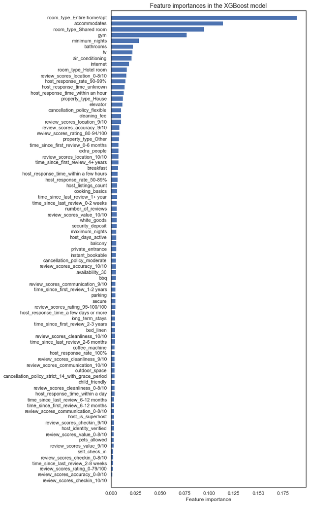

```python
# Plotting feature importances
plt.figure(figsize=(8,20))
plt.barh(ft_weights_xgb_reg.index, ft_weights_xgb_reg.weight, align='center')
plt.title("Feature importances in the XGBoost model", fontsize=14)
plt.xlabel("Feature importance")
plt.margins(y=0.01)
plt.show()
```

There seems to be a heavy importance on amenities available and the number of people a listing accomodates (you could say bathrooms being an influence on that as well). Also of importance is the type of listing - seeing if the listing is an entire home/apartment or a shared room.

### Model 2: three layer neural network

For the initial version of the neural network, a relatively shallow three layer NN will be created. It will consist of densely-connected layers, and use a relu (rectified linear unit) activation function for the hidden layers and a linear activation function for the output layer, as it is being used for a regression task. The loss function will be mean squared error.

```python
# Building the model
nn2 = models.Sequential()
nn2.add(layers.Dense(128, input_shape=(X_train.shape[1],), activation='relu'))
nn2.add(layers.Dense(256, activation='relu'))
nn2.add(layers.Dense(256, activation='relu'))
nn2.add(layers.Dense(1, activation='linear'))

# Compiling the model
nn2.compile(loss='mean_squared_error',
            optimizer='adam',
            metrics=['mean_squared_error'])

# Model summary
print(nn2.summary())
```

```
Model: "sequential_1"
_________________________________________________________________
Layer (type)                 Output Shape              Param #
=================================================================
dense_1 (Dense)              (None, 128)               10496
_________________________________________________________________
dense_2 (Dense)              (None, 256)               33024
_________________________________________________________________
dense_3 (Dense)              (None, 256)               65792
_________________________________________________________________
dense_4 (Dense)              (None, 1)                 257
=================================================================
Total params: 109,569
Trainable params: 109,569
Non-trainable params: 0
_________________________________________________________________
None
```

#### Training the model

```python
nn2_start = time.time()

nn2_history = nn2.fit(X_train,
                  y_train,
                  epochs=250,
                  batch_size=128,
                  validation_split = 0.1)

nn2_end = time.time()

print(f"Time taken to run: {round((nn2_end - nn2_start)/60,1)} minutes")
```

```
Train on 6171 samples, validate on 686 samples
Time taken to run: 0.5 minutes
```

```python
def score_eval(model, skip_epochs=0, X_train=X_train, X_test=X_test, y_train=y_train, y_test=y_test):


    # MSE and r squared values
    y_test_pred = model.predict(X_test)
    y_train_pred = model.predict(X_train)
    print("Training MSE:", round(mean_squared_error(y_train, y_train_pred),4))
    print("Validation MSE:", round(mean_squared_error(y_test, y_test_pred),4))
    print("\nTraining r2:", round(r2_score(y_train, y_train_pred),4))
    print("Validation r2:", round(r2_score(y_test, y_test_pred),4))


def model_evaluation(model, skip_epochs=0, X_train=X_train, X_test=X_test, y_train=y_train, y_test=y_test):


    # MSE and r squared values
    y_test_pred = model.predict(X_test)
    y_train_pred = model.predict(X_train)
    print("Training MSE:", round(mean_squared_error(y_train, y_train_pred),4))
    print("Validation MSE:", round(mean_squared_error(y_test, y_test_pred),4))
    print("\nTraining r2:", round(r2_score(y_train, y_train_pred),4))
    print("Validation r2:", round(r2_score(y_test, y_test_pred),4))

    # Line graph of losses
    model_results = model.history.history
    plt.plot(list(range((skip_epochs+1),len(model_results['loss'])+1)), model_results['loss'][skip_epochs:], label='Train')
    plt.plot(list(range((skip_epochs+1),len(model_results['val_loss'])+1)), model_results['val_loss'][skip_epochs:], label='Test', color='green')
    plt.legend()
    plt.title('Training and test loss at each epoch', fontsize=14)
    plt.show()

    # Scatterplot of predicted vs. actual values
    fig, (ax1, ax2) = plt.subplots(1, 2, figsize=(12, 4))
    fig.suptitle('Predicted vs. actual values', fontsize=14, y=1)
    plt.subplots_adjust(top=0.93, wspace=0)

    ax1.scatter(y_test, y_test_pred, s=2, alpha=0.7)
    ax1.plot(list(range(2,8)), list(range(2,8)), color='black', linestyle='--')
    ax1.set_title('Test set')
    ax1.set_xlabel('Actual values')
    ax1.set_ylabel('Predicted values')

    ax2.scatter(y_train, y_train_pred, s=2, alpha=0.7)
    ax2.plot(list(range(2,8)), list(range(2,8)), color='black', linestyle='--')
    ax2.set_title('Train set')
    ax2.set_xlabel('Actual values')
    ax2.set_ylabel('')
    ax2.set_yticklabels(labels='')

    plt.show()
```

```
Training MSE: 0.0272
Validation MSE: 0.2065

Training r2: 0.9466
Validation r2: 0.5952
```

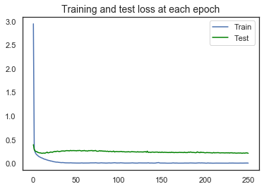

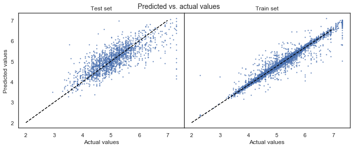

```python
model_evaluation(nn2)
```

Compared to the XGBoost model, the neural network has performed worse. The training set had much better results in the neural network, indicating that overfitting is an issue.

### Model 3: four-layer neural network with L1 regularization and more epochs

To try and reduce over-fitting, L1 regularization will be used. This acts to reduce parameter coefficients (or potentially remove them altogether by setting the coefficient to zero) in order to to reduce model complexity and overfitting. Unlike L2 regularization, L1 regularization performs penalised estimation and selection simultaneously, and so is preferred when the number of predictors is very high.

An extra layer will also be added, to see whether it is able to increase model accuracy (r2).

```python
# Building the model
nn3 = models.Sequential()
nn3.add(layers.Dense(128, input_shape=(X_train.shape[1],), kernel_regularizer=regularizers.l1(0.005), activation='relu'))
nn3.add(layers.Dense(256, kernel_regularizer=regularizers.l1(0.005), activation='relu'))
nn3.add(layers.Dense(256, kernel_regularizer=regularizers.l1(0.005), activation='relu'))
nn3.add(layers.Dense(512, kernel_regularizer=regularizers.l1(0.005), activation='relu'))
nn3.add(layers.Dense(1, activation='linear'))

# Compiling the model
nn3.compile(loss='mean_squared_error',
            optimizer='adam',
            metrics=['mean_squared_error'])

# Model summary
print(nn3.summary())
```

```
Model: "sequential_2"
_________________________________________________________________
Layer (type)                 Output Shape              Param #
=================================================================
dense_5 (Dense)              (None, 128)               10496
_________________________________________________________________
dense_6 (Dense)              (None, 256)               33024
_________________________________________________________________
dense_7 (Dense)              (None, 256)               65792
_________________________________________________________________
dense_8 (Dense)              (None, 512)               131584
_________________________________________________________________
dense_9 (Dense)              (None, 1)                 513
=================================================================
Total params: 241,409
Trainable params: 241,409
Non-trainable params: 0
_________________________________________________________________
None
```

```python
# Training the model
nn3_start = time.time()

nn3_history = nn3.fit(X_train,
                  y_train,
                  epochs=400,
                  batch_size=256,
                  validation_split = 0.1)

nn3_end = time.time()

print(f"Time taken to run: {round((nn3_end - nn3_start)/60,1)} minutes")
```

```
Train on 6171 samples, validate on 686 samples
Time taken to run: 1.0 minutes
```

```
Training MSE: 0.1702
Validation MSE: 0.1911

Training r2: 0.6662
Validation r2: 0.6254
```

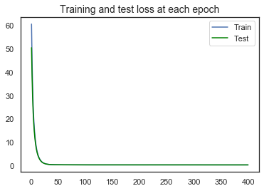

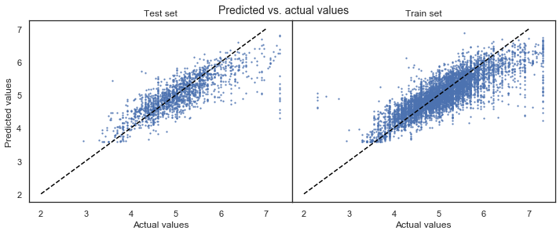

```python
# Evaluating the model
model_evaluation(nn3)
```

Regularization and more layers have increased the r2 value compared to model 2.

### Model 4: neural network with SGD optimizer

```python
# Building the model
nn4 = models.Sequential()
nn4.add(layers.Dense(128, input_shape=(X_train.shape[1],), kernel_regularizer=regularizers.l1(0.005), activation='relu'))
nn4.add(layers.Dense(256, kernel_regularizer=regularizers.l1(0.005), activation='relu'))
nn4.add(layers.Dense(256, kernel_regularizer=regularizers.l1(0.005), activation='relu'))
nn4.add(layers.Dense(512, kernel_regularizer=regularizers.l1(0.005), activation='relu'))
nn4.add(layers.Dense(1, activation='linear'))

# Compiling the model
nn4.compile(loss='mean_squared_error',
            optimizer='SGD',
            metrics=['mean_squared_error'])

# Model summary
print(nn4.summary())
```

```
Model: "sequential_3"
_________________________________________________________________
Layer (type)                 Output Shape              Param #
=================================================================
dense_10 (Dense)             (None, 128)               10496
_________________________________________________________________
dense_11 (Dense)             (None, 256)               33024
_________________________________________________________________
dense_12 (Dense)             (None, 256)               65792
_________________________________________________________________
dense_13 (Dense)             (None, 512)               131584
_________________________________________________________________
dense_14 (Dense)             (None, 1)                 513
=================================================================
Total params: 241,409
Trainable params: 241,409
Non-trainable params: 0
_________________________________________________________________
None
```

```python
# Training the model
nn4_start = time.time()

nn4_history = nn4.fit(X_train,
                  y_train,
                  epochs=250,
                  batch_size=256,
                  validation_split = 0.1)

nn4_end = time.time()

print(f"Time taken to run: {round((nn4_end - nn4_start)/60,1)} minutes")
```

```
Train on 6171 samples, validate on 686 samples
Time taken to run: 0.6 minutes
```

```
Training MSE: 0.1723
Validation MSE: 0.1894

Training r2: 0.6621
Validation r2: 0.6288
```

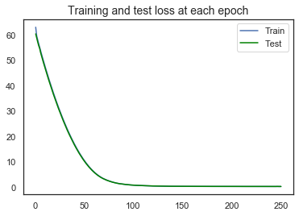

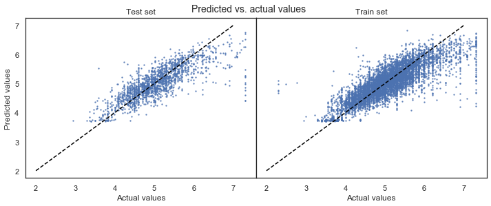

```python
model_evaluation(nn4)
```

### Model 5: removing excess review rating features

So far, a number of hyperparameters have been tuned in order to increase the performance of the NN. Adding extra layers can often increase the performance of a NN, at the cost of increasing computational requirements.

This model will drop review columns other than the overall review rating, and use the same NN structure as Model 3, in order to see whether this produces a better model.

Columns will be dropped from the existing X_train and X_test split, for consistency.

```python
all_review = list(X_train.columns[X_train.columns.str.startswith("review_scores")])
review_to_keep = list(X_train.columns[X_train.columns.str.startswith("review_scores_rating")])
review_to_drop = [x for x in all_review if x not in review_to_keep]

X_train_short = X_train.drop(review_to_drop, axis=1)
X_test_short = X_test.drop(review_to_drop, axis=1)
```

```python
# Building the model
nn5 = models.Sequential()
nn5.add(layers.Dense(128, input_shape=(X_train_short.shape[1],), kernel_regularizer=regularizers.l1(0.005), activation='relu'))
nn5.add(layers.Dense(256, kernel_regularizer=regularizers.l1(0.005), activation='relu'))
nn5.add(layers.Dense(256, kernel_regularizer=regularizers.l1(0.005), activation='relu'))
nn5.add(layers.Dense(512, kernel_regularizer=regularizers.l1(0.005), activation='relu'))
nn5.add(layers.Dense(1, activation='linear'))

# Compiling the model
nn5.compile(loss='mean_squared_error',
            optimizer='adam',
            metrics=['mean_squared_error'])

# Model summary
print(nn5.summary())
```

```
Model: "sequential_4"
_________________________________________________________________
Layer (type)                 Output Shape              Param #
=================================================================
dense_15 (Dense)             (None, 128)               8192
_________________________________________________________________
dense_16 (Dense)             (None, 256)               33024
_________________________________________________________________
dense_17 (Dense)             (None, 256)               65792
_________________________________________________________________
dense_18 (Dense)             (None, 512)               131584
_________________________________________________________________
dense_19 (Dense)             (None, 1)                 513
=================================================================
Total params: 239,105
Trainable params: 239,105
Non-trainable params: 0
_________________________________________________________________
None
```

```python
# Training the model
nn5_start = time.time()

nn5_history = nn5.fit(X_train_short,
                  y_train,
                  epochs=250,
                  batch_size=256,
                  validation_split=0.1)

nn5_end = time.time()

print(f"Time taken to run: {round((nn5_end - nn5_start)/60,1)} minutes")
```

```
Train on 6171 samples, validate on 686 samples
Time taken to run: 0.6 minutes
```

```
Training MSE: 0.1741
Validation MSE: 0.1917

Training r2: 0.6587
Validation r2: 0.6242
```

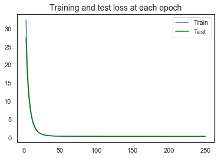

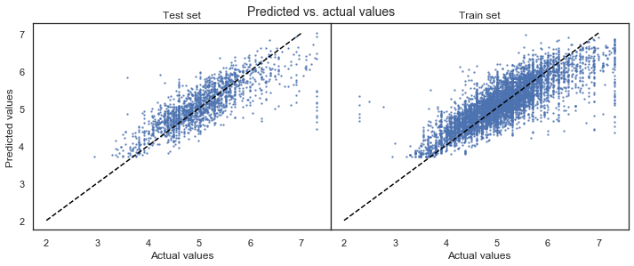

```python
model_evaluation(nn5, skip_epochs=2, X_train=X_train_short, X_test=X_test_short)
```

### Model 6: four-layer neural network with a min-max scaler

```python
# Dropping review columns from the original dataframe (after log transformation)
df_minmax = transformed_df.drop(review_to_drop, axis=1)

# Separating X and y
X_minmax = df_minmax.drop('price', axis=1)
y_minmax = df_minmax.price

# Scaling
scaler = MinMaxScaler(feature_range=(0, 1))
X_minmax = pd.DataFrame(scaler.fit_transform(X_minmax), columns=list(X_minmax.columns))

# Splitting into train and test sets
X_train_minmax, X_test_minmax, y_train_minmax, y_test_minmax = train_test_split(X_minmax, y_minmax, test_size=0.2, random_state=123)
```

```python
# Building the model
nn6 = models.Sequential()
nn6.add(layers.Dense(128, input_shape=(X_train_minmax.shape[1],), kernel_regularizer=regularizers.l1(0.005), activation='relu'))
nn6.add(layers.Dense(256, kernel_regularizer=regularizers.l1(0.005), activation='relu'))
nn6.add(layers.Dense(256, kernel_regularizer=regularizers.l1(0.005), activation='relu'))
nn6.add(layers.Dense(512, kernel_regularizer=regularizers.l1(0.005), activation='relu'))
nn6.add(layers.Dense(1, activation='linear'))

# Compiling the model
nn6.compile(loss='mean_squared_error',
            optimizer='adam',
            metrics=['mean_squared_error'])

# Model summary
print(nn6.summary())
```

```
Model: "sequential_5"
_________________________________________________________________
Layer (type)                 Output Shape              Param #
=================================================================
dense_20 (Dense)             (None, 128)               8192
_________________________________________________________________
dense_21 (Dense)             (None, 256)               33024
_________________________________________________________________
dense_22 (Dense)             (None, 256)               65792
_________________________________________________________________
dense_23 (Dense)             (None, 512)               131584
_________________________________________________________________
dense_24 (Dense)             (None, 1)                 513
=================================================================
Total params: 239,105
Trainable params: 239,105
Non-trainable params: 0
_________________________________________________________________
None
```

```python
# Training the model
nn6_start = time.time()

nn6_history = nn6.fit(X_train_minmax,
                  y_train_minmax,
                  epochs=250,
                  batch_size=256,
                  validation_split = 0.1)

nn6_end = time.time()

print(f"Time taken to run: {round((nn6_end - nn6_start)/60,1)} minutes")
```

```
Train on 6171 samples, validate on 686 samples
Time taken to run: 0.6 minutes
```

```
Training MSE: 0.2075
Validation MSE: 0.226

Training r2: 0.593
Validation r2: 0.5569
```

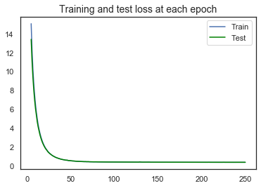

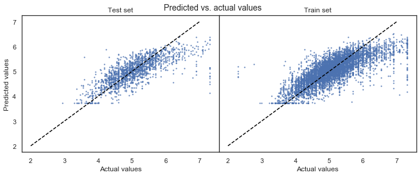

```python
model_evaluation(nn6, skip_epochs=4, X_train=X_train_minmax, X_test=X_test_minmax, y_train=y_train_minmax, y_test=y_test_minmax)
```

### Performance Overview through models 1-6

```python
print('Model 1: XGBoost')
print("Training MSE:", round(mean_squared_error(y_train, training_preds_xgb_reg),4))
print("Validation MSE:", round(mean_squared_error(y_test, val_preds_xgb_reg),4))
print("\nTraining r2:", round(r2_score(y_train, training_preds_xgb_reg),4))
print("Validation r2:", round(r2_score(y_test, val_preds_xgb_reg),4))
print('\n')
print('Model 2: 3-Layer Neural Network')
score_eval(nn2)
print('\n')
print('Model 3: 4-Layer Neural Network with L1 Regularization')
score_eval(nn3)
print('\n')
print('Model 4: Neural Network with SGD Optimizer')
score_eval(nn4)
print('\n')
print('Model 5: removing excess review rating features')
score_eval(nn5, skip_epochs=2, X_train=X_train_short, X_test=X_test_short)
print('\n')
print('Model 6: 4-Layer Neural Network with a min-max Scale')
score_eval(nn6, skip_epochs=4, X_train=X_train_minmax, X_test=X_test_minmax,
           y_train=y_train_minmax, y_test=y_test_minmax)
```

```
Model 1: XGBoost
Training MSE: 0.0298
Validation MSE: 0.1481

Training r2: 0.9415
Validation r2: 0.7098


Model 2: 3-Layer Neural Network
Training MSE: 0.0272
Validation MSE: 0.2065

Training r2: 0.9466
Validation r2: 0.5952


Model 3: 4-Layer Neural Network with L1 Regularization
Training MSE: 0.1702
Validation MSE: 0.1911

Training r2: 0.6662
Validation r2: 0.6254


Model 4: Neural Network with SGD Optimizer
Training MSE: 0.1723
Validation MSE: 0.1894

Training r2: 0.6621
Validation r2: 0.6288


Model 5: removing excess review rating features
Training MSE: 0.1741
Validation MSE: 0.1917

Training r2: 0.6587
Validation r2: 0.6242


Model 6: 4-Layer Neural Network with a min-max Scale
Training MSE: 0.2075
Validation MSE: 0.226

Training r2: 0.593
Validation r2: 0.5569
```

# Conclusion

Other models, like **Model 3 with L1 regularization** and **Model 4 with SGD Optimizers**, performed closely with the XGboost model. Other regularization methods may prove to be useful or beneficial.

**Model 5 with removed review ratings** also performed closely with **Model 1** and **Model 4**, and could potentially show that hyperparameter tuning can further improve the accurate predictions of price on an AirBnB listing.

### Potential Shortcomings and Ways to Improve Future Models

- Find a method to incorporate image quality into the model by using the output of a convolutional neural network to assess image quality as an input into the pricing model
- Use better quality/more accurate data which includes the actual average prices paid per night. More data in general could be useful.
- Include a wider geographic area, like all of California, or the west region of the US.
- Support the model with natural language processing (NLP) of listing descriptions and/or reviews, e.g. for sentiment analysis or looking for keywords